# rmarkdown restart with git

joe

14/07/2020

So knit - html. To setup git need repository created first? in github, then create project of same name in R with options git. >>> followed this : https://community.rstudio.com/t/rstudio-git-commit-not-associated-with-github-account/27633/2 TO: https://happygitwithr.com/rstudio-git-github.html

Then need to stage? files to have them uploaded.

Next create a web page in github. Followed: Khan academy, https://www.khanacademy.org/computing/computer-programming/html-css/web-development-tools/a/hosting-your-website-on-github >>> Make sure to name your project exactly “YOUR_USERNAME.github.io”. That tells Github that you’re making a special webpage project

but it looks like you can do it for any repository, GITHUB Docs: >>>https://docs.github.com/en/github/working-with-github-pages/creating-a-github-pages-site

Then uploaded the rmarkdown html file. Modified the index.html file from the web page created by Khan:

Test project web page r studio markdown : in web page folder [r studio markdown : project rmkdwn](https://jo-mc.github.io/rmkdwn/init.html)

ALso uploaded the init.html form the rmkdwn project.

So the local ref for init.html (which I manually drage and dropped into the web page project works - it did take several minutes for the page to work)

The second method via the rmkdwn project does not seem to work. ??

## “Day2”

#### author: “joe”

#### date: “15/07/2020”

#### output: html_document

DATA: HG005_sumcount.mpu, /data/rc003/joe/CCS/chinese_trio/pileup_200+

```
chr1 10467 10         1 1
chr1 10966 5          2 2
chr1 66218 64         1 3
```

FROM:

> grep -o -n ‘[+]’ HG005.mpu | cut -d : -f 1 | uniq -c > HG005_+count.mpu paste HG005_sum.mpu HG005_+count.mpu > HG005_sumcount.mpu

R import filtered data from pileup:

df <- read.table(“C:/BIGDATA______TEMPORARY/chinese_trio_pileup_200+/HG005_sumcount.mpu”)

> x1 <- c(“chr2”)

> sub <- df[df$V1 %in% x1,3]

This is correct chr2 has 3690 values. row 3 is the read depth

AND :PLOT:

> y <- df[df$V1 %in% x1,3]

> x <- df[df$V1 %in% x1,2]

> plot(x,y)

**Insert figure from file:**

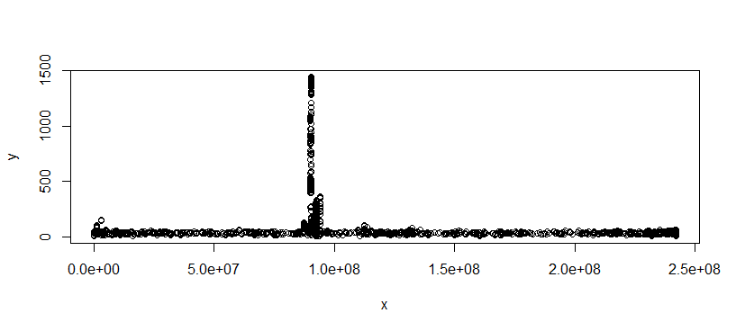

**Insert figure with r code:**

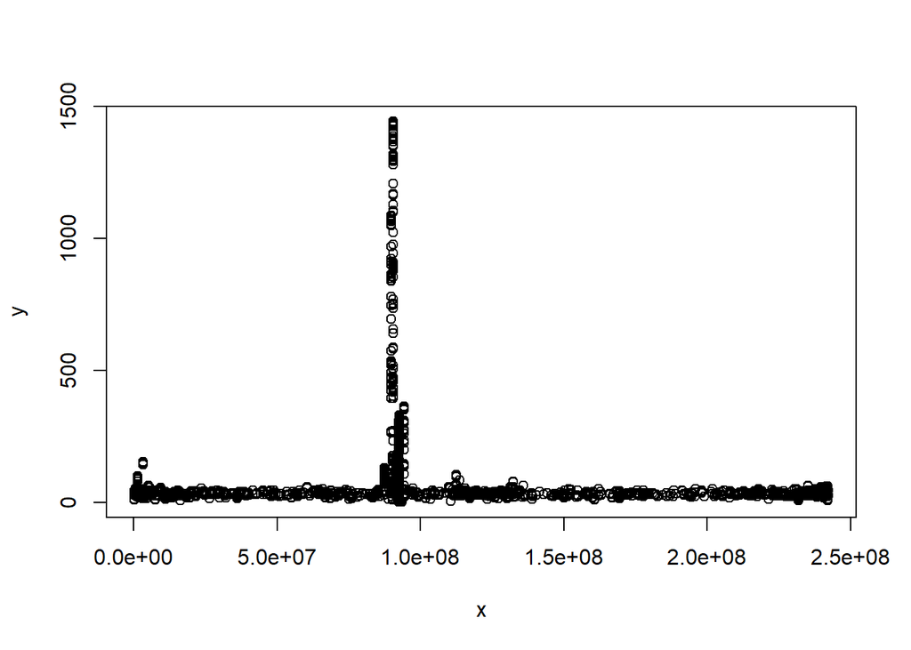

[output not shown]

```r
df <- read.table("C:/BIGDATA______TEMPORARY/chinese_trio_pileup_200+/HG005_sumcount.mpu")
x1 <- c("chr2")
 y <- df[df$V1 %in% x1,3]
 x <- df[df$V1 %in% x1,2]
 plot(x,y)
```